# Girls Baseline CAPI Summaries

Chuck Cleland

June 19, 2017 06:05:27 PM EDT

# Load Required R Packages

```r
library(readr)
library(data.table)
library(dplyr)
library(tidyr)
library(ggplot2)
library(scales)
```

# Read in CSV Data

```r
DF <- read_csv(file = "c:/chuck/NYU/Kurth/High Yield Testing/Data/01___BASELINE_BEHAVIORAL_SURVEY___GIRLS____19th_June_2017_results.csv")
names(DF) <- gsub(":", "_", names(DF))

DF <- as.data.table(DF)
```

# Interview Date

| date | n | Percent |
| --- | --- | --- |
| 2017-05-31 | 5 | 6.7 |
| 2017-06-02 | 6 | 8.0 |
| 2017-06-05 | 7 | 9.3 |
| 2017-06-06 | 10 | 13.3 |
| 2017-06-07 | 7 | 9.3 |
| 2017-06-08 | 8 | 10.7 |
| 2017-06-09 | 5 | 6.7 |
| 2017-06-12 | 7 | 9.3 |
| 2017-06-13 | 8 | 10.7 |
| 2017-06-14 | 5 | 6.7 |
| 2017-06-15 | 6 | 8.0 |
| 2017-06-16 | 1 | 1.3 |

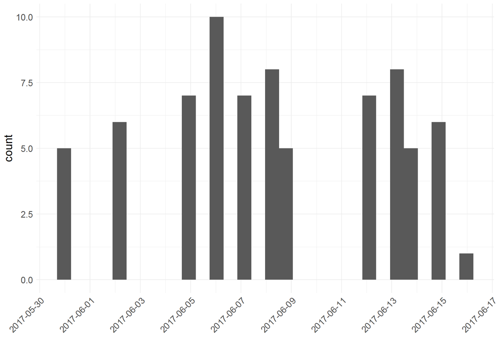

# Interviewer

| InterNo | n | Percent |
| --- | --- | --- |
| 6 | 19 | 25.3 |
| 8 | 17 | 22.7 |
| 9 | 15 | 20.0 |
| 10 | 12 | 16.0 |
| 12 | 12 | 16.0 |

# Module 1: Demographics

## Age at Last Birthday

| Q2 | n | Percent |
| --- | --- | --- |
| 15 | 2 | 2.7 |
| 16 | 3 | 4.0 |
| 17 | 3 | 4.0 |
| 18 | 5 | 6.7 |
| 19 | 16 | 21.3 |
| 20 | 9 | 12.0 |
| 21 | 10 | 13.3 |
| 22 | 13 | 17.3 |
| 23 | 14 | 18.7 |

| n | Mean | sd | Median | IQR | Min | Max |
| --- | --- | --- | --- | --- | --- | --- |
| 75 | 20.28 | 2.153313 | 20 | 3 | 15 | 23 |

## School Attendance

| School Attendance | n | Percent |
| --- | --- | --- |
| Currently Attending | 13 | 17.3 |
| In the past, but not currently | 62 | 82.7 |

## What is the highest level of school you attended or are currently attending?

| Q5 | n | Percent |
| --- | --- | --- |
| Primary | 26 | 34.7 |
| Secondary | 40 | 53.3 |
| University | 7 | 9.3 |
| Vocational/Training | 2 | 2.7 |

## What is the highest class/form/year completed at that level?

| Q6 | n | Percent |
| --- | --- | --- |
| C/7 | 1 | 1.3 |
| C/8 | 4 | 5.3 |
| C6 | 3 | 4.0 |
| C7 | 3 | 4.0 |
| C7/2012 | 2 | 2.7 |
| C7/2013 | 1 | 1.3 |
| C8 | 10 | 13.3 |
| C8/2012 | 1 | 1.3 |
| C8/2013 | 1 | 1.3 |
| College/2016 | 1 | 1.3 |
| F/1 | 1 | 1.3 |
| F/2 | 1 | 1.3 |
| F/3 | 2 | 2.7 |
| F/4 | 1 | 1.3 |
| F1 | 1 | 1.3 |
| F1/2010 | 1 | 1.3 |
| F1/2012 | 1 | 1.3 |
| F1/2017 | 1 | 1.3 |
| F2 | 5 | 6.7 |
| F2/2011 | 1 | 1.3 |
| F2/2014 | 1 | 1.3 |
| F3 | 4 | 5.3 |
| F4 | 15 | 20.0 |
| F4/2013 | 1 | 1.3 |
| F4/2014 | 1 | 1.3 |
| F4/2016 | 3 | 4.0 |
| University | 1 | 1.3 |
| Y/2 | 1 | 1.3 |
| Y/3 | 1 | 1.3 |
| Y1 | 1 | 1.3 |
| Y2 | 4 | 5.3 |

## Where do you live (county, division, location)?

| CountyLive | SubCountyLive | DivisionLive | n | Percent |
| --- | --- | --- | --- | --- |
| Homa_Bay | Homabay_Town | Asego | 75 | 100 |

## Do you live alone?

| Q8 | n | Percent |
| --- | --- | --- |
| No | 66 | 88 |
| Yes | 9 | 12 |

## If you don’t live alone, do you live with family, others, or a student hostel?

| Q9 | n | Percent |
| --- | --- | --- |
| I live with my family | 56 | 84.8 |
| Other | 10 | 15.2 |

## How many people live in your home?

| n | Mean | sd | Median | IQR | Min | Max |
| --- | --- | --- | --- | --- | --- | --- |
| 66 | 4.560606 | 2.113173 | 4 | 2 | 2 | 13 |

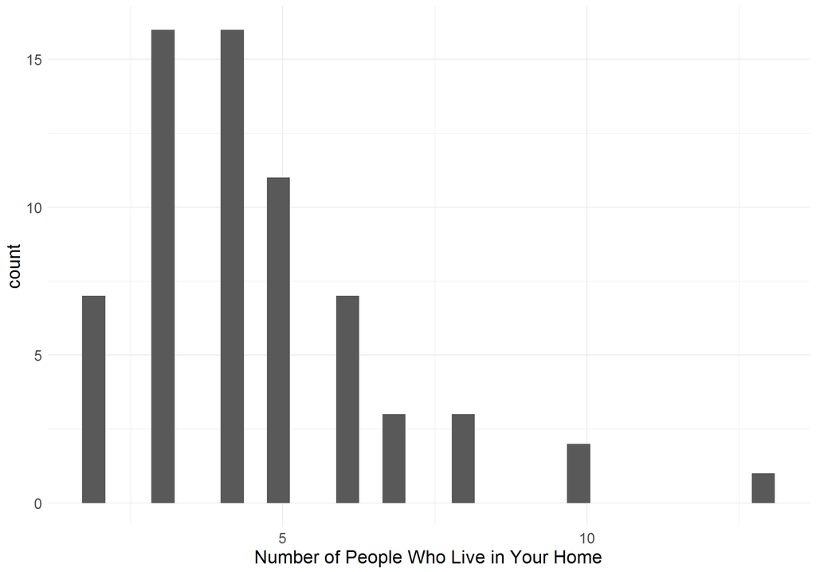

## How long have you lived at your current physical address?

| Q11 | n | Percent |
| --- | --- | --- |
| 1-3 years | 36 | 48.0 |
| 4+ years | 26 | 34.7 |
| Less than one year | 13 | 17.3 |

## What is your current marital status?

| Q12 | n | Percent |
| --- | --- | --- |
| Married, monogamous | 35 | 46.7 |
| Married, polygamous | 4 | 5.3 |
| Single (no current relationship) | 35 | 46.7 |
| Widowed | 1 | 1.3 |

## What was your main source of income in the past 6 months?

| Q13 | n | Percent |
| --- | --- | --- |
| Informally employed | 6 | 8.0 |
| No work, receive money from my family, friends, partner | 49 | 65.3 |
| Other | 8 | 10.7 |
| Self-employed | 11 | 14.7 |
| Subsistence farming | 1 | 1.3 |

## Do you have access to a cell phone number where you could be reached privately/securely/confidentially?

| Q14 | n | Percent |
| --- | --- | --- |
| No | 11 | 14.7 |
| Yes | 64 | 85.3 |

## To whom does the cell phone number belong?

| Q15 | n | Percent |
| --- | --- | --- |
| Friend (romantic) | 2 | 3.1 |
| Mother | 3 | 4.7 |
| Sibling (brother sister) | 1 | 1.6 |
| Spouse | 6 | 9.4 |
| You | 52 | 81.2 |

# Module 2: Drug Use, Violence, and Mood

## Have you ever drunk alcohol, including beer, or local brew such as changaa?

## During the past 30 days, on how many times did you have at least one drink of alcohol?

## How often do you have a drink containing alcohol?

## How many standard drinks containing alcohol do you have on a typical day?

## How often do you have six or more drinks on one occasion?

## How many times in the last 30 days have you used a drug for non-medical, recreational reasons?

## What drug did you use most often in the last 30 days?

## Has someone you were dating or going out with ever physically hurt you on purpose?

## Have you ever physically hurt someone you were dating or going out with on purpose?

## Over the last 2 weeks, how often have you been bothered by any of the following problems? (PHQ-2)

### Little interest or pleasure in doing things

### Feeling down, depressed or hopeless

# Module 3: Health Promotion Services

## Where is the best place for you to receive information about sex and ways to protect yourself from sexually transmitted diseases, HIV/AIDS, and unwanted pregnancy?

| Q27 | n | Percent |
| --- | --- | --- |
| Family Planning Clinic | 2 | 2.7 |
| Government hospital or clinic | 49 | 65.3 |
| Mobile health clinic | 7 | 9.3 |
| Other | 1 | 1.3 |
| Private Doctor | 1 | 1.3 |
| Private Hospital or clinic | 14 | 18.7 |
| School | 1 | 1.3 |

## Have any of these issues ever stopped, delayed or discouraged you from getting, or continuing with, professional care for a health problem?

### Fear of being judged or embarrassed

| Checked | n | Percent |
| --- | --- | --- |
| FALSE | 68 | 90.7 |
| TRUE | 7 | 9.3 |

### I don’t want other people to see me there

| Checked | n | Percent |
| --- | --- | --- |
| FALSE | 72 | 96 |
| TRUE | 3 | 4 |

### I have no money to pay

| Checked | n | Percent |
| --- | --- | --- |
| FALSE | 69 | 92 |
| TRUE | 6 | 8 |

### Location is too far away

| Checked | n | Percent |
| --- | --- | --- |
| FALSE | 66 | 88 |
| TRUE | 9 | 12 |

### My parent’s or caregiver’s reaction

[output not shown]

### My boyfriend’s/girlfriend’s reaction

| Checked | n | Percent |
| --- | --- | --- |
| FALSE | 75 | 100 |

### I do not have transportation

| Checked | n | Percent |
| --- | --- | --- |
| FALSE | 71 | 94.7 |
| TRUE | 4 | 5.3 |

### Services are not friendly towards youth

| Checked | n | Percent |
| --- | --- | --- |
| FALSE | 69 | 92 |
| TRUE | 6 | 8 |

### I don’t know where to get services

| Checked | n | Percent |
| --- | --- | --- |
| FALSE | 72 | 96 |
| TRUE | 3 | 4 |

### I don’t feel it is necessary

| Checked | n | Percent |
| --- | --- | --- |
| FALSE | 75 | 100 |

### I don’t want to know the results of any tests

| Checked | n | Percent |
| --- | --- | --- |
| FALSE | 74 | 98.7 |
| TRUE | 1 | 1.3 |

### Provider will not take my concerns seriously

| Checked | n | Percent |
| --- | --- | --- |
| FALSE | 72 | 96 |
| TRUE | 3 | 4 |

### Religious beliefs

| Checked | n | Percent |
| --- | --- | --- |
| FALSE | 75 | 100 |

### The wait at the clinic is too long

| Checked | n | Percent |
| --- | --- | --- |
| FALSE | 67 | 89.3 |
| TRUE | 8 | 10.7 |

### There is nothing stopping me

| Checked | n | Percent |
| --- | --- | --- |
| FALSE | 24 | 32 |
| TRUE | 51 | 68 |

# Module 4: Sexual Behaviors

## Have you ever had sexual intercourse?

| Q31 | n | Percent |
| --- | --- | --- |
| No | 31 | 41.3 |
| Yes | 44 | 58.7 |

# Module 5: HIV Counseling and Testing

# Module 6: Pre-Exposure Prophylaxis

# Module 7: Antiretroviral Therapy

# Module 8: Family Planning